# Deques

Struktur data yang ketiga adalah Deques. Jika pada stacks, penambahan data baru dan penghapusan dilakukan pada ujung yang sama, yaitu top, sedangkan pada queues, penambahan data baru dan penghapusan dilakukan pada ujung yang berbeda, yaitu rear(penambahan data) dan front(penghapusan data). Maka struktur data deques dapat dilakukan di kedua ujung, seperti halnya queues, hanya terdapat sedikit perbedaan. penambahan data dapat dilakukan pada kedua ujung, baik front maupun rear. Begitu juga halnya dengan penghapusan data yang dapat dilakukan pada front maupun rear.

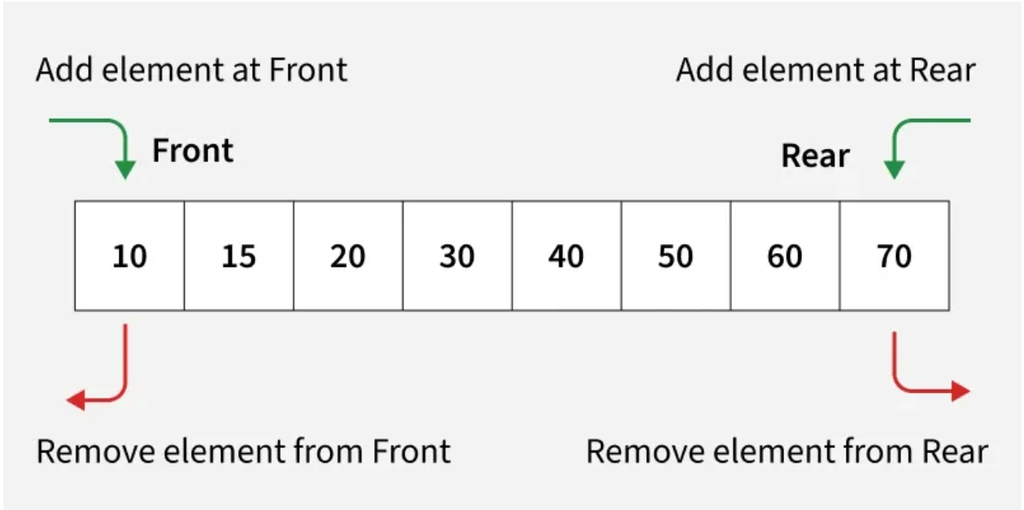

### Operasi Deques

Operasi-operasi yang terdapat pada Deques antara lain :

- deque (), inisialisasi struktur data deque kosong
- addFront (data), penambahan data baru di ujung front pada deque
- addRear (data), penambahan data baru di ujung rear pada deque
- removeRear (), penghapusan data pada ujung rear
- removeFront (), penghapusan data pada ujung front
- isEmpty(), pengecekan apakah deque dalam keadaan kosong
- size (), informasi jumlah data yang terdapat pada deque

Struktur data Deques ini direpresentasikan dengan List, dimana:

- indeks awal list, yaitu indeks ke-0, adalah posisi **front** pada deques
- indeks akhir list, yaitu indeks terakhir, adalah posisi **rear** pada deques

Oleh karena itu, penambahan data baru pada posisi **front** dapat dilakukan dengan method insert() pada posisi ke-0. Sedangkan penambahan data baru pada posisi **rear** dapat dilakukan dengan method append , yang merupakan penambahan data baru pada list di posisi terakhir.

Sedangkan penghapusan data pada posisi **front** dapat dilakukan dengan method pop() pada posisi ke-0, sedangkan penghapusan data pada posisi **rear** dilakukan dengan method pop() .

Code

Berikut adalam implementasi deques dengan menggunakan List :

```python
def createDeque():
    d=[]
    return (d)
def addFront(d,data):
    d.insert(0,data)
    return(d)
def addRear(d,data):
    d.append(data)
    return(d)
def removeRear(d):
    data=d.pop()
    return(data)
def removeFront(d):
    data=d.pop(0)
    return(data)
def isEmpty(d):
    return (d==[])
def size(d):
    return (len(d))
```

Berikut ini adalah contoh penggunan deques

```python
deq=createDeque()

addFront(deq,'struktur')
addFront(deq,'data')

addRear(deq,'2018')
addRear(deq,'2019')

addRear(deq,'100')

data=removeFront(deq)
print(data)
print(deq)
```

```
data
['struktur', '2018', '2019', '100']
```

### Implementasi Deques

Contoh implementasi Deques adalah pengecekan apakah suatu kata merupakan palindrom. Palindrom merupakan rangkaian kata atau bilangan yang terbaca sama baik dari depan maupun dari belakang.

Struktur data **deques** paling tepat digunakan untuk memeriksa apakah suatu kata maupun bilangan adalah palindrom. Untuk memeriksa apakah suatu kata adalah palindrome, dapat dilakukan dengan memeriksa apakah ujung yang terletak pada front dan ujung yang terletak pada rear, merupakan karakter yang sama.

```python
def cekPalindrom(string):
    palindrom=createDeque()
    for huruf in string:
        addRear(palindrom,huruf)
        cek=True
    while size(palindrom)>1:
        a=removeRear(palindrom)
        b=removeFront(palindrom)
        if (a==b):
            cek=cek and True
        else:
            cek=cek and False
    return cek
```

```python
print(cekPalindrom('hannah'))
print(cekPalindrom('surabaya'))
print(cekPalindrom('abcdcba'))
print(cekPalindrom('katak'))
print(cekPalindrom('taat'))
print(cekPalindrom('dia'))
```

```
True
False
True
True
True
False
```

### Soal-soal

1. Jelaskan konsep deque.

Deque (Double Ended Queue) adalah struktur data yang:

Bisa tambah data di depan (front) dan belakang (rear) Bisa hapus data dari depan dan belakang

2. Simulasi antrian prioritas.

```python
def enqueue_prioritas(queue, data, prioritas):
    queue.append((data, prioritas))
    queue.sort(key=lambda x: x[1])

def dequeue(queue):
    if len(queue) == 0:
        print("Kosong")
    else:
        return queue.pop(0)

q = []
enqueue_prioritas(q, "A", 2)
enqueue_prioritas(q, "B", 1)
enqueue_prioritas(q, "C", 3)
print(q)
```

```
[('B', 1), ('A', 2), ('C', 3)]
```

3. Perbedaan queue dan deque.

Queue:

- FIFO (depan-belakang)
- enqueue & dequeue
- Kurang fleksibel

Deque:

- Bisa dua arah
- addFront, addRear, removeFront, removeRear
- Lebih fleksibel
4. Cek Palindrome menggunakan Deque

```python
def palindrome(kata):
    d = list(kata)

    while len(d) > 1:
        if d.pop(0) != d.pop():
            return "Bukan palindrome"

    return "Palindrome"

print(palindrome("KATAK"))
print(palindrome("BUKU"))
```

```
Palindrome
Bukan palindrome
```

5. Tentukan isi akhir deque.

Operasi:

- addFront(1) → [1]
- addRear(2) → [1, 2]
- addFront(3) → [3, 1, 2]
- removeRear() → [3, 1]
- addRear(4) → [3, 1, 4]

Jawaban akhir: [3, 1, 4]